# Lecture 3: Sampling and Inferential Statistics

L2 - Statistics

Gustave Kenedi

2026-02-06

## Recap quiz

[figure not shown]

Or click here: [link to Wooclap](https://app.wooclap.com/L2STATSUM?from=instruction-slide)

## Today’s lecture

**1. Sampling: an example**

2. Statistical inference

3. Quantifying uncertainty

# Sampling: an example

## Political polling

Imagine you are the campaign manager of a new political candidate: Pumpernickel. She wants to know the share of the population who will vote for her. How would you proceed?

1. *Ask every single voter in the country who they intend to vote for?*

$\rightarrow$ Too costly: only **survey** a fraction or **sample** of the population.

2. *What characteristics of the sample?*

$\rightarrow$ How **many** people do you survey? How would you select them?

3. *Once you’ve conducted your survey, would you get the exact share of voters?*

$\rightarrow$ Probably not: you obtain an **estimate** of this share.

## Population vs. sample

**Definitions**

- **Population:** the entire group about which we want information, denoted $N$.
- **Sample:** the fraction of the population for which we collect information, denoted $n$.
- **Sampling rate:** ratio between the sample size and the population size, denoted $t = n/N$.
- **Sampling error:** the error incurred when the statistical characteristics of a population are estimated from a sample of that population.

Goal: use information from the sample to draw conclusions about the population as a whole. In order to ensure *accurate* inferences about the population, the sample needs to be **representative** of the population.

## Sampling

When it is **costly** to collect information on the whole population, and you want to know some characteristics of a population, you only survey a sample of individuals.

Two main challenges:

1. **Selecting** the sample
2. Measuring the **level of uncertainty** on the statistics you get

## Selection and sampling

**How to ensure your sample is representative ?**

- For you, the easiest way of surveying people could be to do so at the Cergy RER A station and ask people as they exit the station.

$\rightarrow$ Does it sound like a good idea? Why?

- Very likely that this is a **biased** sample, in the sense that it is not representative of the **population of interest** (French voters)
- The best way of making a representative sample of the population of interest is to randomly select the individuals who are included in the sample

  – You can do so if you have access to the exhaustive list of individuals in the population of interest: the **sample frame**

  – Having access to the exhaustive list of observations of a population is most of the time difficult

## Random sample

**Definition**

The random variables $X_1, ..., X_n$ are called a **random sample of size n from a population** if $X_1, ..., X_n$ are mutually independent random variables and each $X_i$ has the same probability distribution. Alternatively, $X_1, ..., X_n$ are called *independent and identically distributed random variables.* This is commonly abbreviated to i.i.d. random variables.

## Random sampling

Let’s imagine the population of interest is 1,000 individuals.

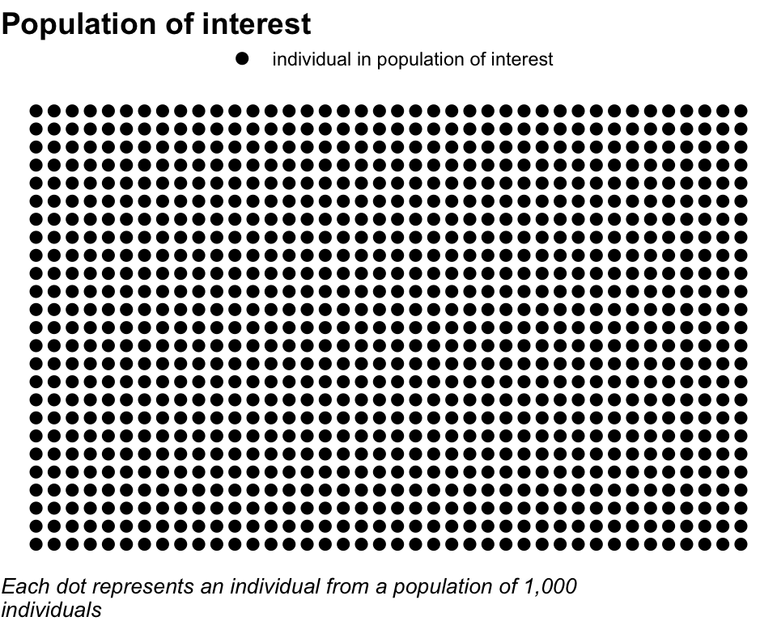

We make some simplifying assumptions:

- individuals truthfully report their voting intentions
- their current preferences correspond to their preferences on election day

## Random sampling

Let’s imagine the population of interest is 1,000 individuals.

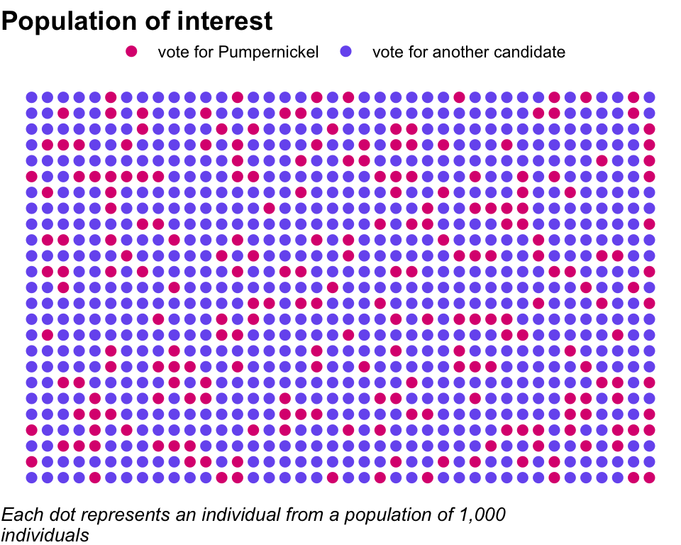

We make some simplifying assumptions:

- individuals truthfully report their voting intentions
- their current preferences correspond to their preferences on election day
- we know that Pumpernickel’s vote share is 23%

  – 0.23 is the true population proportion (denoted $p$)

## Random sampling

Let’s imagine the population of interest is 1,000 individuals.

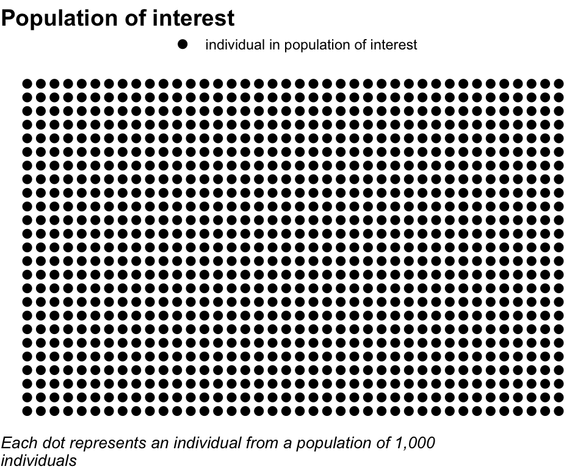

- In pratice, you do not know the true population parameter.
- Let’s survey 20 individuals
- We ensure they are selected at random

## Random sampling

Let’s imagine the population of interest is 1,000 individuals.

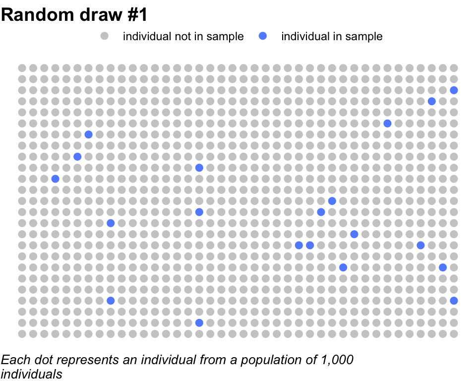

- In pratice, you do not know the true population parameter.
- Let’s survey 20 individuals
- We ensure they are selected at random

## Random sampling

Let’s imagine the population of interest is 1,000 individuals.

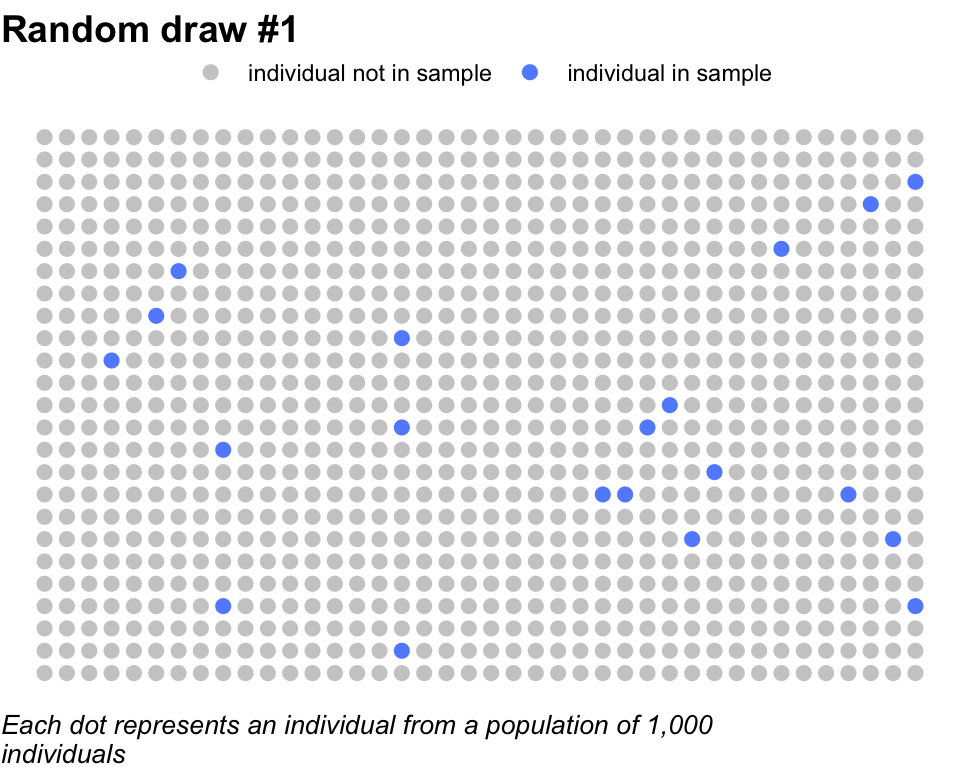

- In pratice, you do not know the true population parameter.
- Let’s survey 20 individuals
- We ensure they are selected at random
- How many report they will vote for Pumpernickel?

## Random sampling

Let’s imagine the population of interest is 1,000 individuals.

- In pratice, you do not know the true population parameter.
- Let’s survey 20 individuals
- We ensure they are selected at random
- How many report they will vote for Pumpernickel?

5 will vote for Pumpernickel out of 20 = 25%

0.25 can be thought of as our guess of the vote share for Pumpernickel

## Parameters and statistics

- We denote our *guess* of the vote share for Pumpernickel $\hat{p}$.
- The $\hat{\text{ }}$ denotes that this statistic has been estimated.
- It corresponds to the estimate of the population parameter $p$, which is the true vote share for Pumpernickel.

The goal for the class is for the estimates to be good guesses for the population parameters:

$$\text{Data} \rightarrow \text{Calculation} \rightarrow \hat{\text{Estimates}} \xrightarrow{\text{hopefully!}} \text{Truth}$$

For example,

$$X \rightarrow \frac{1}{n}\sum_{i=1}^{n}X_i \rightarrow \bar{x} \xrightarrow{\text{hopefully!}} \mu$$

## Sampling variation

- What would happen if we took a new sample? Would we also get 5 Pumpernickel voters as before?
- What if we repeated this survey multiple times?
- Probably not. The samples will vary from draw to draw.
- Key to this observation: these are randomly drawn samples.

## Sampling variation

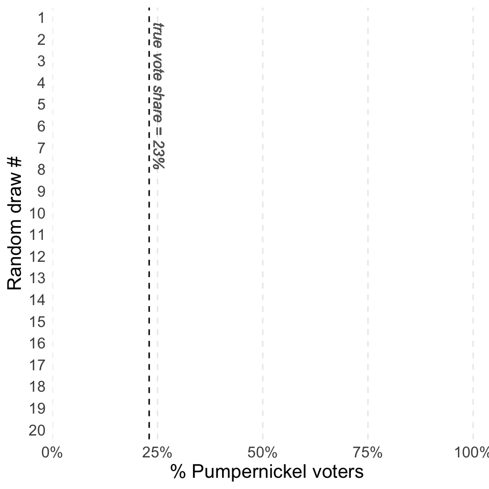

## Sampling variation

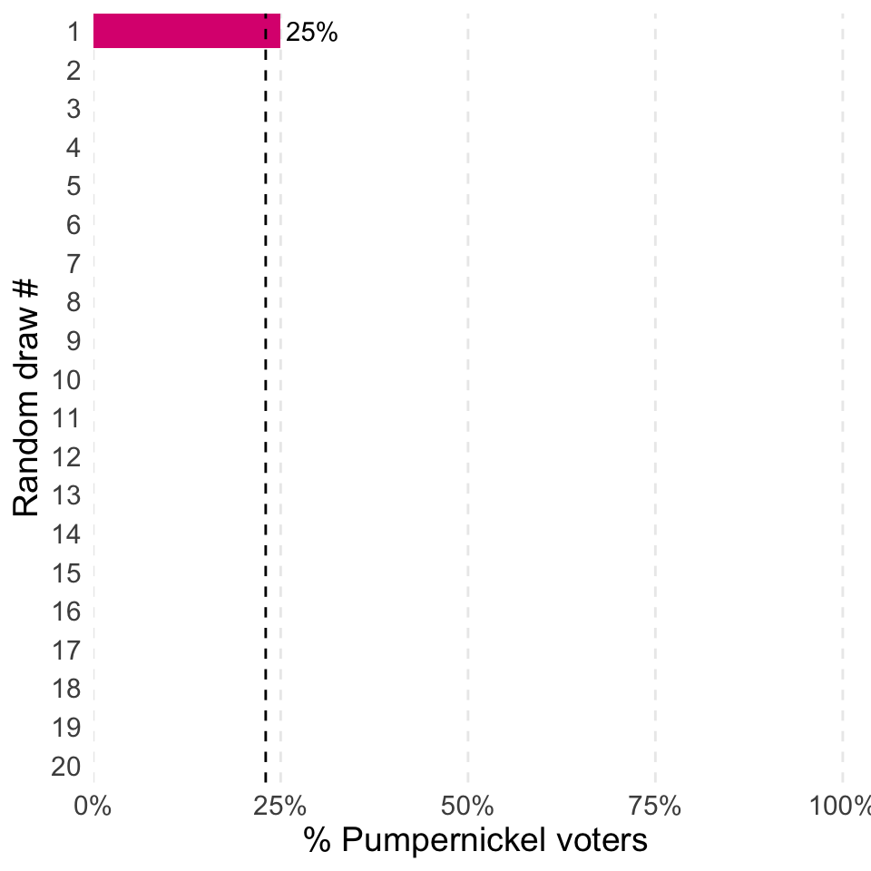

## Sampling variation

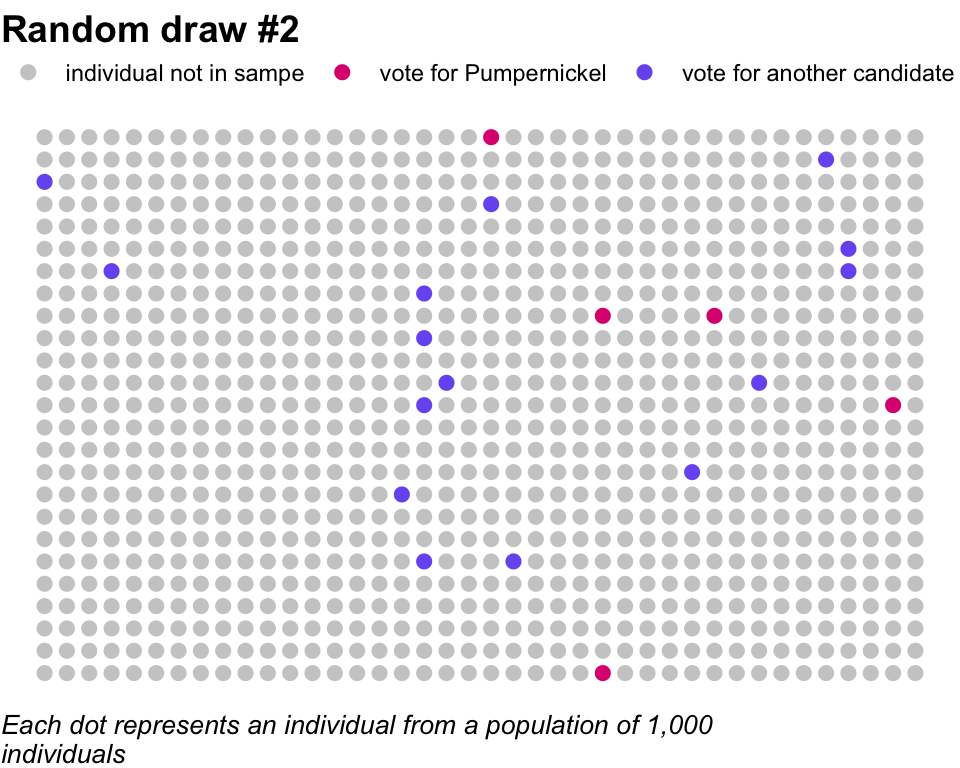

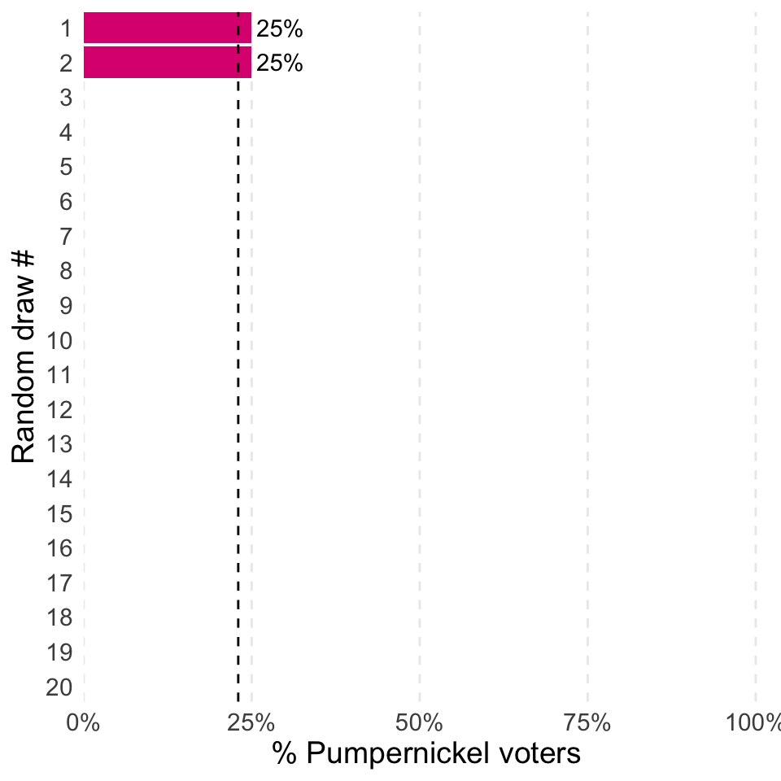

## Sampling variation

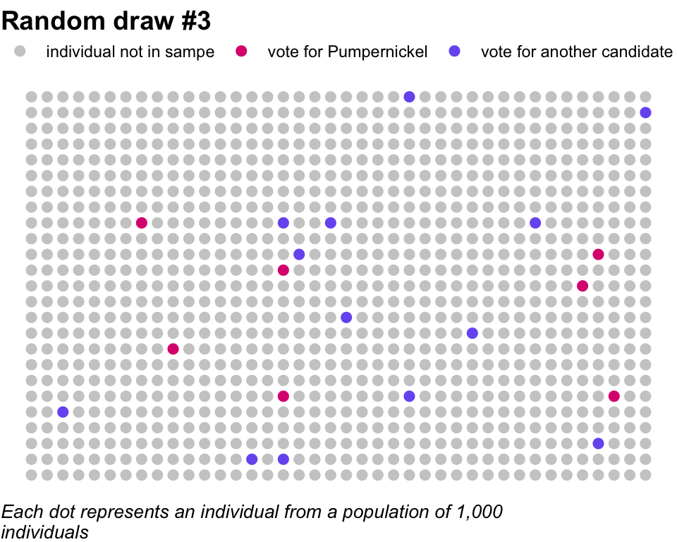

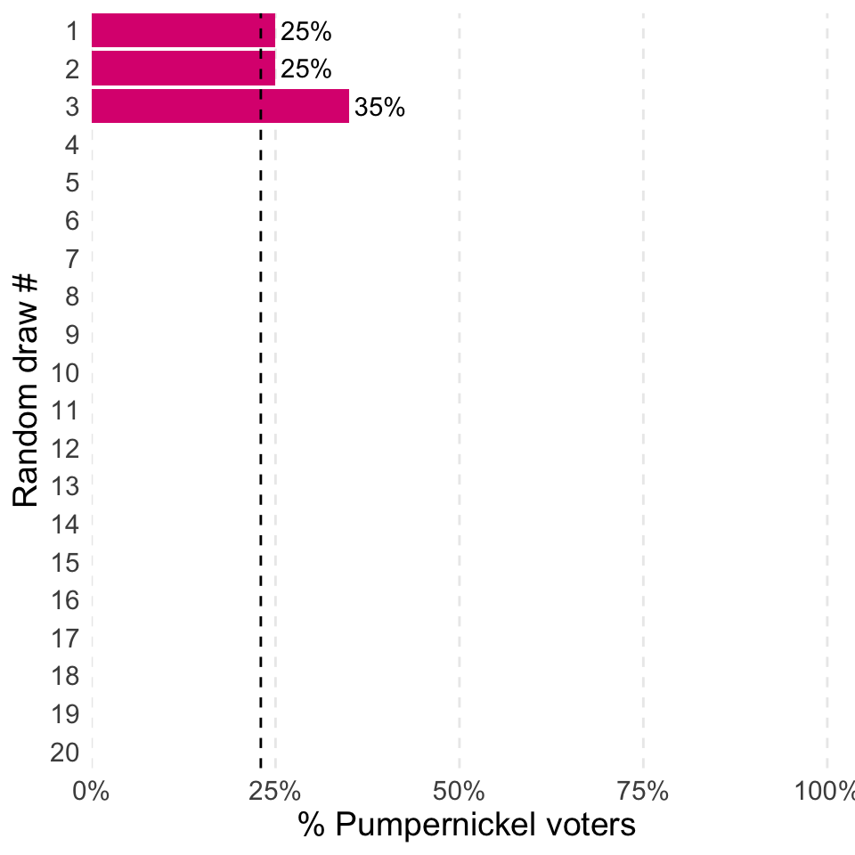

## Sampling variation

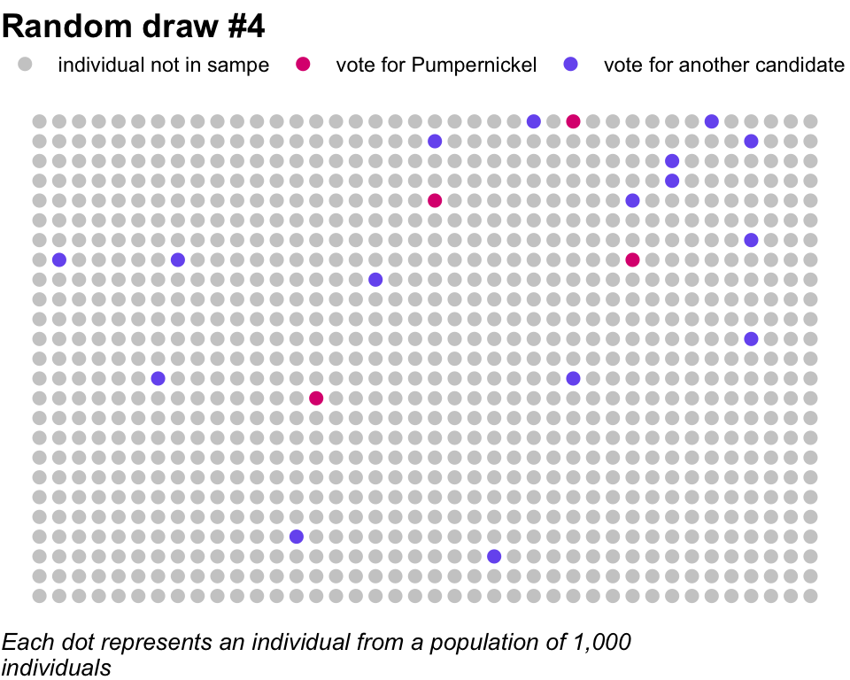

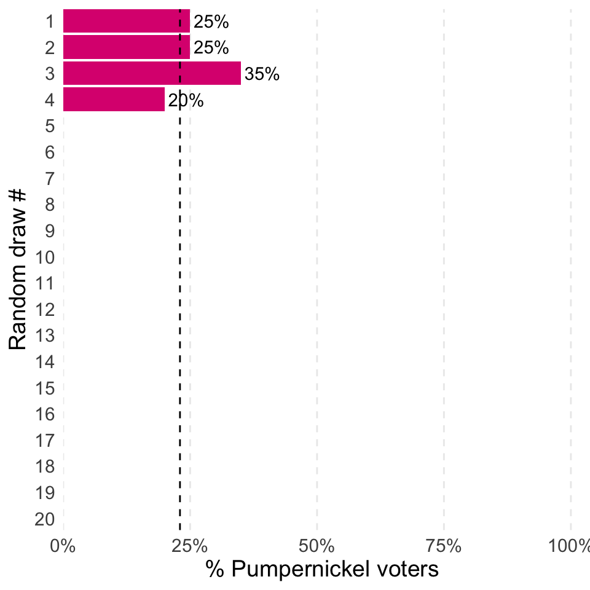

## Sampling variation

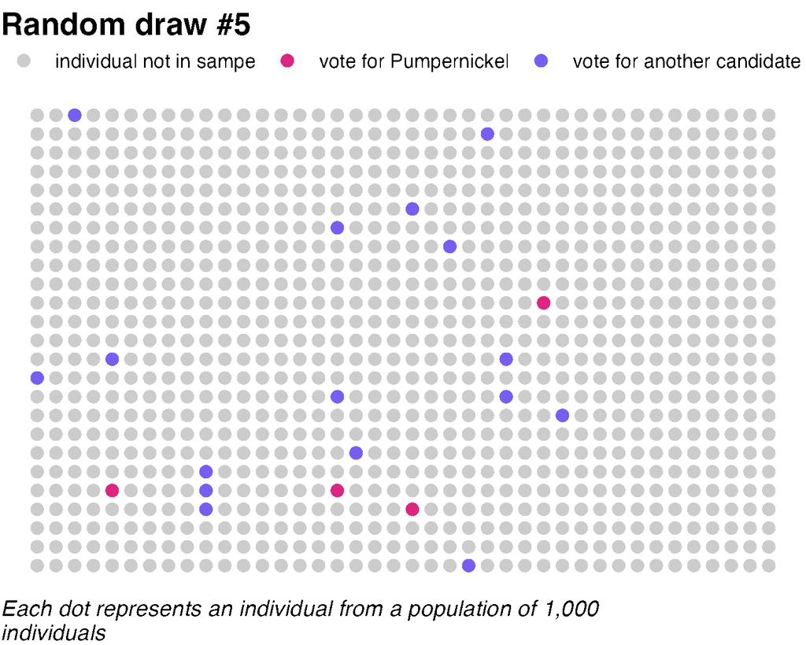

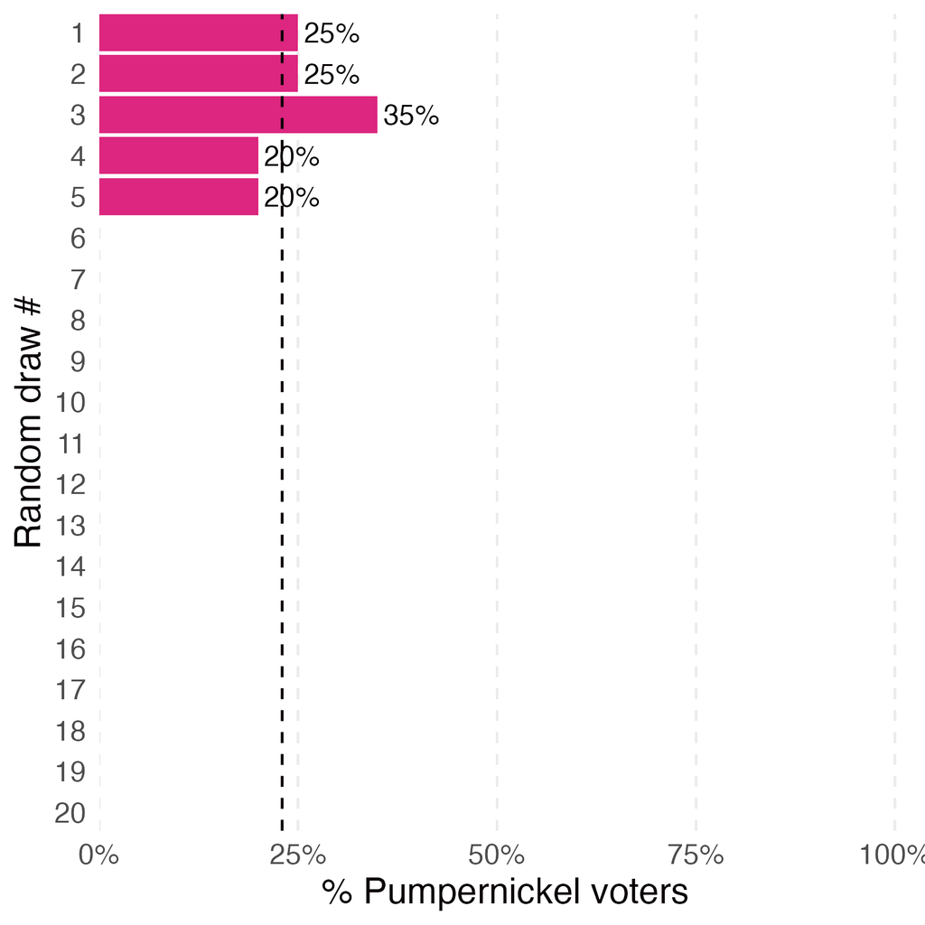

## Sampling variation

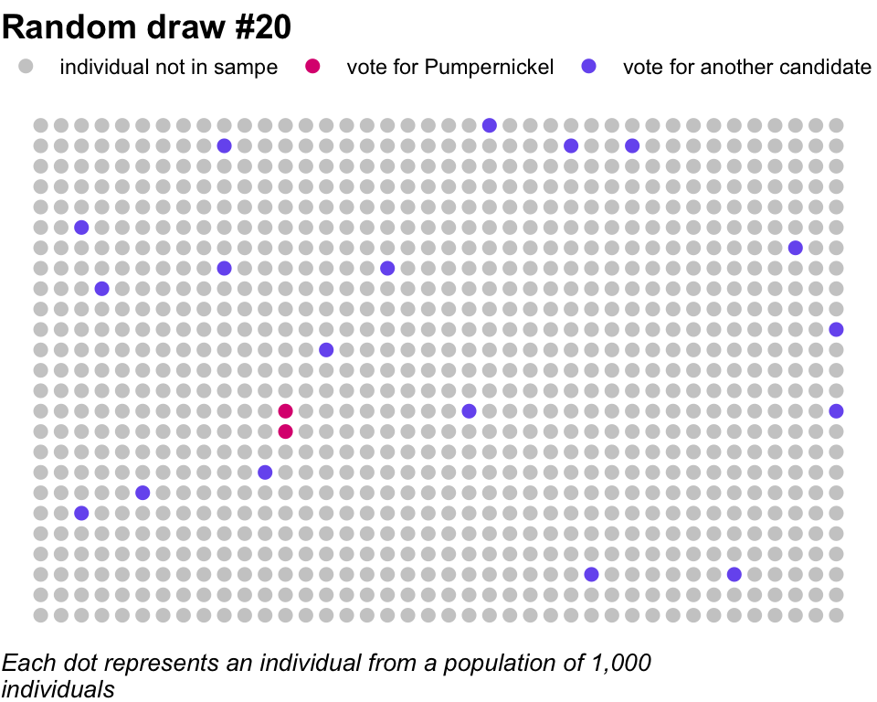

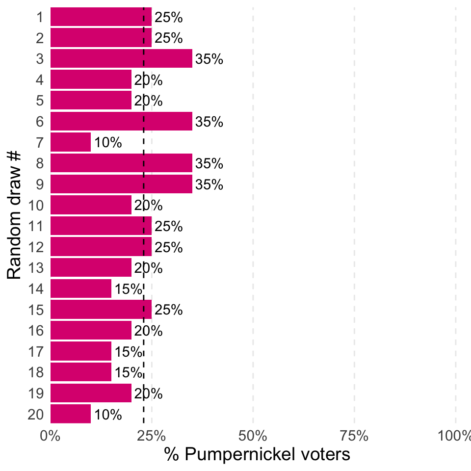

## Your turn! #1

1. Create a data.frame containing the proportions of Pumpernickel voters from the previous slide. Name it `vote_share` and name the variable containing the proportions `prop_votes`. (Hint: to create a data.frame you need to use the data.frame() function.) The proportions are as follows: `(0.25, 0.25, 0.35, 0.20, 0.20, 0.35, 0.1, 0.35, 0.35, 0.2, 0.25, 0.25, 0.2, 0.15, 0.25, 0.2, 0.15, 0.15, 0.2, 0.1)`.
2. Create a histogram of these proportions using `ggplot2.`
3. What do you observe?

## Sampling distribution: histogram

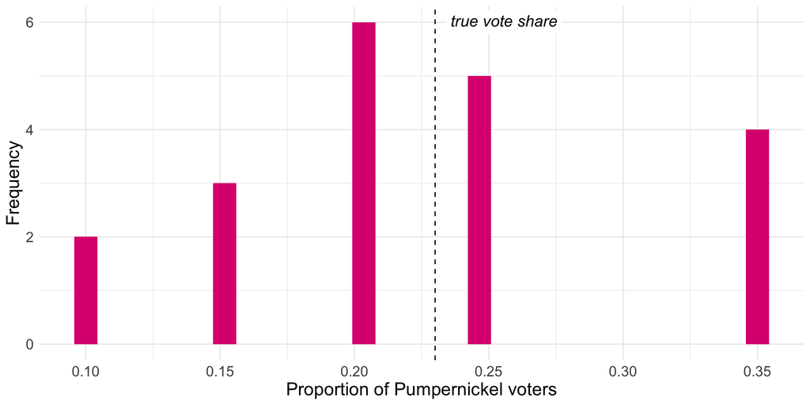

## What did we just do?

- Demonstrated the statistical concept of sampling
- *Objective*: know the proportion of Pumpernickel voters, $p$
- *Methods:*
  - Census: time-consuming (and in many cases very costly);
  - Random Sampling: extract a sample of 20 voters from the population to obtain an estimate, $\hat{p}$. Our first estimate of the proportion of Pumpernickel voters was 0.25, and it turned out to be around the mean of our other estimates
- *Important:* each sample was drawn randomly $\rightarrow$ samples are different from each other!  
  $\rightarrow$ different proportions 👉 sampling variation

## Lesson 2 of statistics: sampling variation is everywhere!

This graph applies to all estimates:

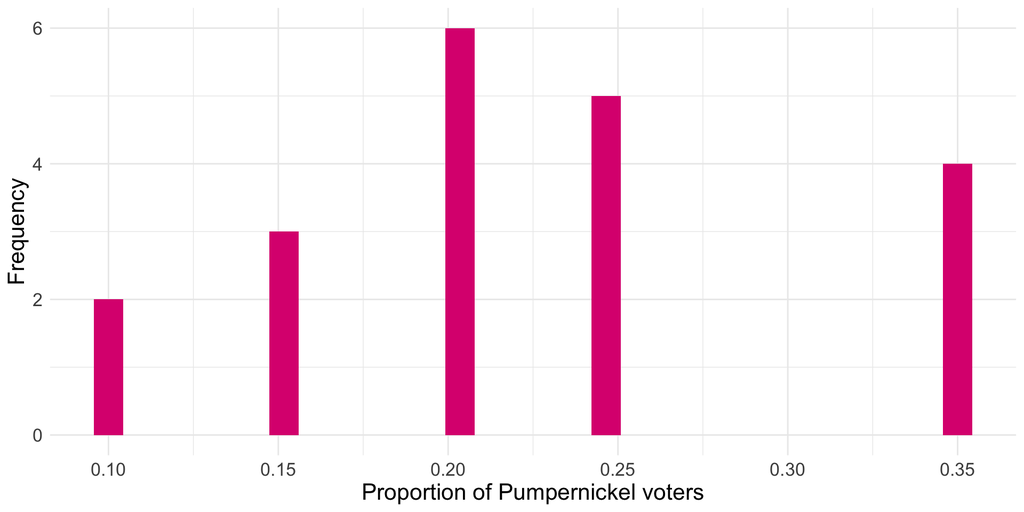

## Taking random samples

- All the voters in the population are stored in a csv file [here](https://www.dropbox.com/scl/fi/bizhr0jjvrzm4kyhggvos/population_clean.csv?rlkey=ryeswyb5mgbvvdqaptwtleybj&dl=1)

```r
# voter_population <- read.csv("https://www.dropbox.com/scl/fi/bizhr0jjvrzm4kyhggvos/population_clean.csv?rlkey=ryeswyb5mgbvvdqaptwtleybj&dl=1")

voter_population <- read.csv("data/population_clean.csv")

head(voter_population)
```

```
  voter_id       candidate
1        1 Other candidate
2        2 Other candidate
3        3 Other candidate
4        4 Other candidate
5        5    Pumpernickel
6        6 Other candidate
```

2 variables:

- `voter_id`: voter identifier
- `candidate`: candidate of voter

```r
nrow(voter_population)
```

```
[1] 1000
```

- Let’s take *virtual* draws from our voter population.
- We’ll use the virtual shovel to take a sample of 50 voters from our voting population.

## Using a virtual shovel once

- We will take a first sample of size 50 this time, using the `moderndive` function `rep_sample_n`.

```r
library(moderndive) # load moderndive package, remember to install before if not already done

virtual_shovel <- voter_population |>  # notice that moderndive functions can be "pipped"
  rep_sample_n(size = 50) # take a sample of 50 voters
```

```r
# display the sample's first 6 rows
head(virtual_shovel)
```

```
# A tibble: 6 × 3
# Groups:   replicate [1]
  replicate voter_id candidate
      <int>    <int> <chr>
1         1      287 Other candidate
2         1      466 Other candidate
3         1      530 Other candidate
4         1      995 Other candidate
5         1      488 Other candidate
6         1      814 Pumpernickel
```

- Column `replicate` tells us the ID of the sample. Here: `1`.

```r
# number of observations in sample
nrow(virtual_shovel)
```

```
[1] 50
```

## Proportion of Pumpernickel voters

```r
sample_1 <- virtual_shovel |>
  summarise(
    # number of observations in sample
    n_sample = n(),
    # number of Pumpernickel voters in sample
    n_pumpernickel = sum(candidate == "Pumpernickel")) |>
  mutate(
    # proportion of Pumpernickel voters in sample
    prop_pumpernickel = n_pumpernickel / n_sample)
sample_1
```

```
# A tibble: 1 × 4
  replicate n_sample n_pumpernickel prop_pumpernickel
      <int>    <int>          <int>             <dbl>
1         1       50             13              0.26
```

1. Compute:
- number of observations in sample (i.e. 50 in this case)
- number of Pumpernickel voters in sample,
2. Compute proportion of Pumpernickel voters

👉 0.26 are Pumpernickel voters! This is an estimate of the proportion of Pumpernickel voters in the population What if we try again?

What if we try many times, like, 100 times?

## Using the virtual shovel 100 times

100 samples (replicates) of size 50.

```r
virtual_samples <- voter_population |>
  # get 100 samples of size 50
  rep_sample_n(size = 50, reps = 100)
virtual_samples
```

```
# A tibble: 5,000 × 3
# Groups:   replicate [100]
   replicate voter_id candidate
       <int>    <int> <chr>
 1         1      912 Other candidate
 2         1      551 Other candidate
 3         1      352 Other candidate
 4         1      833 Other candidate
 5         1      862 Pumpernickel
 6         1      826 Other candidate
 7         1      217 Pumpernickel
 8         1      696 Pumpernickel
 9         1      683 Other candidate
10         1      451 Other candidate
# ℹ 4,990 more rows
```

Compute the proportion of Pumpernickel voters in each sample.

```r
virtual_prop_pumpernickel <- virtual_samples |>
  group_by(replicate) |>
  summarise(prop_pumpernickel = mean(candidate == "Pumpernickel"))
virtual_prop_pumpernickel
```

```
# A tibble: 100 × 2
   replicate prop_pumpernickel
       <int>             <dbl>
 1         1              0.26
 2         2              0.2
 3         3              0.2
 4         4              0.28
 5         5              0.28
 6         6              0.3
 7         7              0.3
 8         8              0.26
 9         9              0.3
10        10              0.22
# ℹ 90 more rows
```

## Sampling variation

- Just as before, the virtual sampler also creates random samples.
- The `prop_pumpernickel` column in the `virtual_prop_pumpernickel` data.frame differs across samples.
- And again, we can visualize the sampling distribution:

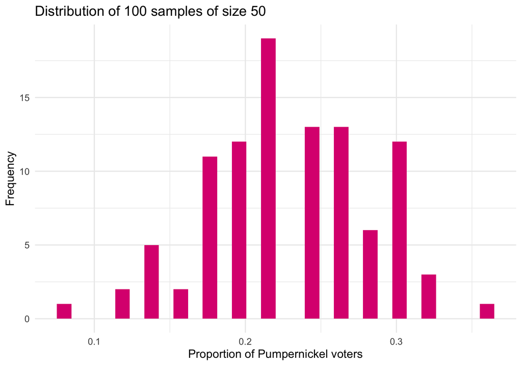

```r
virtual_prop_pumpernickel |>
  ggplot(aes(x = prop_pumpernickel)) +
  geom_histogram(fill = "#DC267F") +
  labs(x = "Proportion of Pumpernickel voters",
       y = "Frequency",
       title = "Distribution of 100 samples of size 50") +
  theme_minimal(base_size = 16)
```

## Your turn! #2

Instead of taking only 100 samples, let’s take `1000`!

## Sampling distribution of 1,000 samples

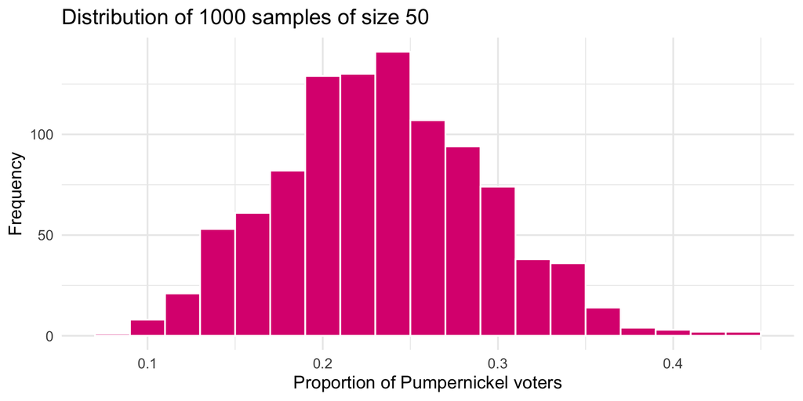

Looks remarkably close to a *normal distribution* $\rightarrow$ the more samples we take, the more their *sampling distribution* will resemble a *normal distribution*

## Role of sample size

Imagine you could change the size of your samples and had the option of the following sizes: 25, 50 and 100.

If your goal is still to estimate the share of Pumpernickel voters in the population, which sample size would you choose?

## Role of sample size

Let’s repeat what we did previously but for different sample sizes.

Let’s take 1000 samples each for $n = 25$, $n = 50$, $n = 100$.

We will use `rep_sample_n()`again.

Generate all samples of different sizes:

```r
# Sample size: 25
virtual_samples_25 <- voter_population |>
  rep_sample_n(size = 25, reps = 1000)

# Sample size: 50
virtual_samples_50 <- voter_population |>
  rep_sample_n(size = 50, reps = 1000)

# Sample size: 100
virtual_samples_100 <- voter_population |>
  rep_sample_n(size = 100, reps = 1000)
```

Compute proportion of Pumpernickel voters

```r
# Sample size: 25
virtual_prop_voters_25 <- virtual_samples_25 |>
  group_by(replicate) |>
  summarise(prop_pumpernickel = mean(candidate == "Pumpernickel"),
            sample_n = n())
```

## Role of sample size

Comparison of sampling distribution under different sample sizes

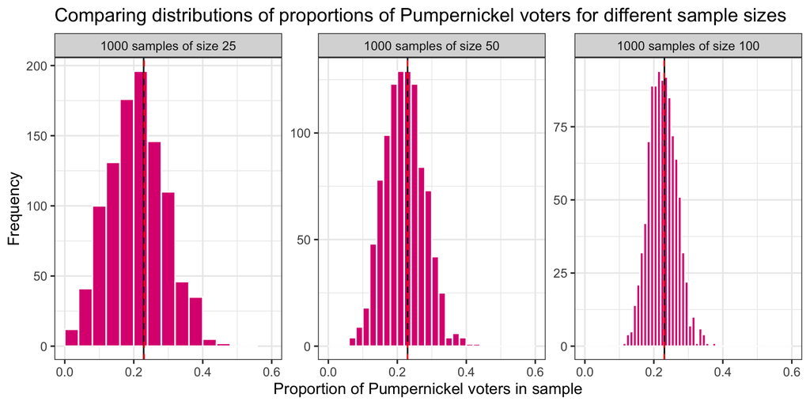

## Sample size and sampling distributions

- The larger the sample size, the narrower the resulting sampling distribution.
- In other words, there are fewer differences due to sampling variation.
- Holding constant the number of replicates (i.e. 1000 in our case), **bigger samples** will yield normal distributions with **smaller standard deviations**.

| Sample Size | Mean | Standard Deviation |
| --- | --- | --- |
| 25 | 0.2287 | 0.0826 |
| 50 | 0.2299 | 0.0578 |
| 100 | 0.2306 | 0.0401 |

- Remember that the standard deviation measures the *spread* of a variable around its mean.
- So as the sample size increases, our estimates of the true proportion of Pumpernickel voters gets more *precise*.

## Today’s lecture

1. Sampling: an example

**2. Statistical inference**

3. Quantifying uncertainty

# Statistical inference

## Parameter and statistics

We have discussed using sample data to make inference about the population.

A parameter is a number that describes the population. In practice, parameters are unknown because we cannot examine the entire population.

A statistic is a number that can be calculated from sample data without using any unknown parameters. In practice, we use statistic to **estimate** parameters.

**Definition**

Let $X_1, ..., X_n$ be a random sample of size $n$ from a population and let $g(x_1, ..., x_n)$ be a function of the realizations of $(X_1, ..., X_n)$. Then the random variable (or random vector) $T_n = g(X_1, ..., X_n)$ is called a (sample) **statistic**. The probability distribution of a statistic $T_n$ is called the **sampling distribution** of $T_n$.

We will denote $t_n = g(x_1, ..., x_n$) the realization of this random variable for a realization of the sample $(x_1, ..., x_n)$.

## Sample mean: definition

Let $X_1, ..., X_n$ be a *random sample* from a population with mean $\mu$ and variance $\sigma^2 < \infty$. The sample mean is the arithmetic average of the values in a random sample:

$$\bar{X_n} = \frac{X_1 + X_2 + ... + X_n}{n} = \frac{1}{n} \sum_{i=1}^{n} X_i$$

We denote $\bar x$ the realization of the random variable $\bar{X_n}$:

$$\bar{x} = \frac{x_1 + x_2 + ... + x_n}{n} = \frac{1}{n} \sum_{i=1}^{n} x_i$$

**Key insight:** the sample mean is a **random variable**! It changes from sample to sample, and therefore has a probability distribution (as we saw earlier).

## Sample mean: properties

**Question:** On average, does $\bar{X_n}$ equal the population mean $\mu$?

**Answer:** Yes! Let’s prove it:

$$\mathbb{E}[\bar{X_n}] = \mathbb{E}\left[\frac{1}{n} \sum_{i=1}^n X_i\right]$$

Using linearity of expectation:

$$= \frac{1}{n} \sum_{i=1}^n \mathbb{E}[X_i] = \frac{1}{n} \sum_{i=1}^n \mu = \frac{1}{n} \cdot n\mu = \mu$$

**Conclusion:** $\boxed{\mathbb{E}[\bar{X_n}] = \mu}$ ✓

We say that the sample mean is an **unbiased** estimator of $\mu$!

## Sample mean: precision

**Question:** How spread out is the distribution of $\bar{X_n}$?

**Answer:** We can calculate the variance of the sample mean, the sampling variance of the sample mean.

$$\mathbb{V}(\bar{X_n}) = \mathbb{V}\left(\frac{1}{n} \sum_{i=1}^n X_i\right) = \frac{1}{n^2} \mathbb{V}\left( \sum_{i=1}^n X_i\right)$$

Since the $X_i$ are independent and each have variance $\sigma^2$:

$$= \frac{1}{n^2} \sum_{i=1}^n \mathbb{V}(X_i) = \frac{1}{n^2} \cdot n\sigma^2 = \frac{\sigma^2}{n}$$

**Conclusion:** $\boxed{\mathbb{V}(\bar{X_n}) = \frac{\sigma^2}{n}}$ ✓

## Variance of sample mean

This last result is important: it states that **the larger the sample, the more precise our estimate of the mean** (as we saw earlier).

| Sample Size | Mean | Standard Deviation | $\sigma/\sqrt(n)$ |
| --- | --- | --- | --- |
| N = 1000 | $\mu$ = 0.23 | $\sigma$ = 0.421 |  |
| 25 | 0.2287 | 0.0826 | 0.0842 |
| 50 | 0.2299 | 0.0578 | 0.0595 |
| 100 | 0.2306 | 0.0401 | 0.0421 |

The standard deviation of a statistic has a very important name: the standard error.

## Variance of sample mean

This last result is important: it states that **the larger the sample, the more precise our estimate of the mean** (as we saw earlier).

| Sample Size | Mean | Standard Error | $\sigma/\sqrt(n)$ |
| --- | --- | --- | --- |
| N = 1000 | $\mu$ = 0.23 | $\sigma$ = 0.421 |  |
| 25 | 0.2287 | 0.0826 | 0.0842 |
| 50 | 0.2299 | 0.0578 | 0.0595 |
| 100 | 0.2306 | 0.0401 | 0.0421 |

The standard deviation of a (sample) statistic has a very important name: the standard error.

It plays a central role in how we make *statistical inferences*.

## The weak law of large numbers (WLLN)

**Definition**

Let $X_1, ..., X_n$ be i.i.d. random variables with a finite expected value $\mathbb{E}[X_i] = \mu$ and $\mathbb{V}(X_i) = \sigma^2 < \infty$. Then, for every $\epsilon > 0$,

$$\lim_{n \rightarrow \infty} P(|\bar{X_n} - \mu| < \epsilon) = 1.$$

We say that the sample mean, $\bar{X_n}$, *converges in probability* to $\mu$. In other words, **as sample size increases, the sample mean will equal the population mean**.

## Illustration: WLLN in action

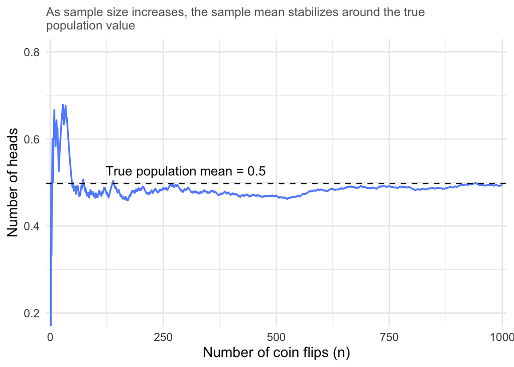

## Properties of estimators

**Definition**

A (point) **estimator**, $\hat{\theta}$, is any function $g(X_1, ..., X_n)$ of a sample; that is, any (sample) **statistic** is a (point) estimator.

*Example:* suppose you are interested in *estimating* the average income in France. Denoting $X$ the random variable of income in France, you are effectively interested in $\mathbb{E}[X]$. What are the *desirable* properties of **estimators** of $\mathbb{E}[X]$?

1. Unbiasedness: an estimator, $\hat{\theta}$, is *unbiased* for $\theta$ if $\mathbb{E}[\hat{\theta}] = \theta$. The *bias* of $\hat{\theta}$ in estimating $\theta$ is equal to $B = \mathbb{E}[\hat{\theta}] - \theta$.

$\rightarrow$ we saw earlier that the sample mean $\bar{X_n}$ is an **unbiased** estimator of the population mean.

While unbiasedness is desirable (*on average*, the estimator equals the true value), it does not guarantee our estimator will usually be close to the true value.

## Properties of estimators

**Definition**

A (point) **estimator**, $\hat{\theta}$, is any function $g(X_1, ..., X_n)$ of a sample; that is, any (sample) **statistic** is a (point) estimator.

*Example:* suppose you are interested in *estimating* the average income in France. Denoting $X$ the random variable of income in France, you are effectively interested in $\mathbb{E}[X]$. What are the *desirable* properties of **estimators** of $\mathbb{E}[X]$?

2. Consistency: an estimator $\hat{\theta}$ is *consistent* for $\theta$ if $\hat{\theta}$ *converges in probability* to $\theta$.

In words: if we have a **large sample**, our **estimate $\hat{\theta}$ is very likely close to the true $\theta$**.

$\rightarrow$ we saw earlier the WLLN states that the sample mean $\bar{X_n}$ is a **consistent** estimator of the population mean.

## Sample variance and standard deviation: definitions

The *sample variance* is:

$$S_n^2 = \frac{1}{n} \sum_{i=1}^{n} (X_i - \bar{X})^2$$

The *sample standard deviation* is: $S_n = \sqrt{S^2}$

## Sample variance properties

**Question:** Is the sample variance an unbiased estimator of the population variance? (Recall: *an estimator $\hat{\theta}$ is unbiased for $\theta$ if $\mathbb{E}[\hat{\theta}] = \theta$.*)

**Answer:** No! Let’s prove it together.

## Your turn! #3

Let $X_1, ..., X_n$ be i.i.d. random variables with a finite expected value $E[X_i] = \mu$ and $\mathbb{V}(X_i) = \sigma^2 < \infty$.

1. Show that $\mathbb{E}[S_n^2] = \mathbb{E}[X^2] - \mathbb{E}[\bar{X_n}^2]$.
2. Show that $\mathbb{E}[X^2] = \sigma^2 + \mu^2$. *Hint: recall the formula for the variance using expectations.*
3. Show that $\mathbb{E}[\bar{X_n}^2] = \frac{\sigma^2}{n} + \mu^2$. *Hint: the formula for $\mathbb{V}(\bar{X_n})$ will be useful.*
4. Combine the above results to show that $\mathbb{E}[S_n^2] \neq \sigma^2$.
5. Load this [voter data](https://www.dropbox.com/scl/fi/lnz14t3a2cj6kw0l217yo/pumpernickel_voter.csv?rlkey=4dupeb3v1ibxfb1y6283tq403&dl=1). Use `R` to compute the variance of Pumpernickel voters: (1) manually (i.e., taking the sum of deviations from the mean), and (2) using the `var` command. What do you notice?
6. Read the help `sd` (it is simpler than `var`) command’s help file to see if you can understand what’s going on.

## Bessel’s correction

The bias problem is solved with **Bessel’s correction**. Instead of dividing by $n$, we divide by $(n-1)$:

$$S_n^2 = \frac{1}{n-1} \sum_{i=1}^n (X_i - \bar{X_n})^2$$

Now the estimator is **unbiased** for the population variance:

$$\boxed{\mathbb{E}[S_n^2] = \sigma^2 \quad} ✓$$

Note: this unbiased estimator of the sample variance is typically referred to as the **sample variance**. This is what the `R` command `var` (or `sd`) computes!

## Illustration: the biased estimator alone

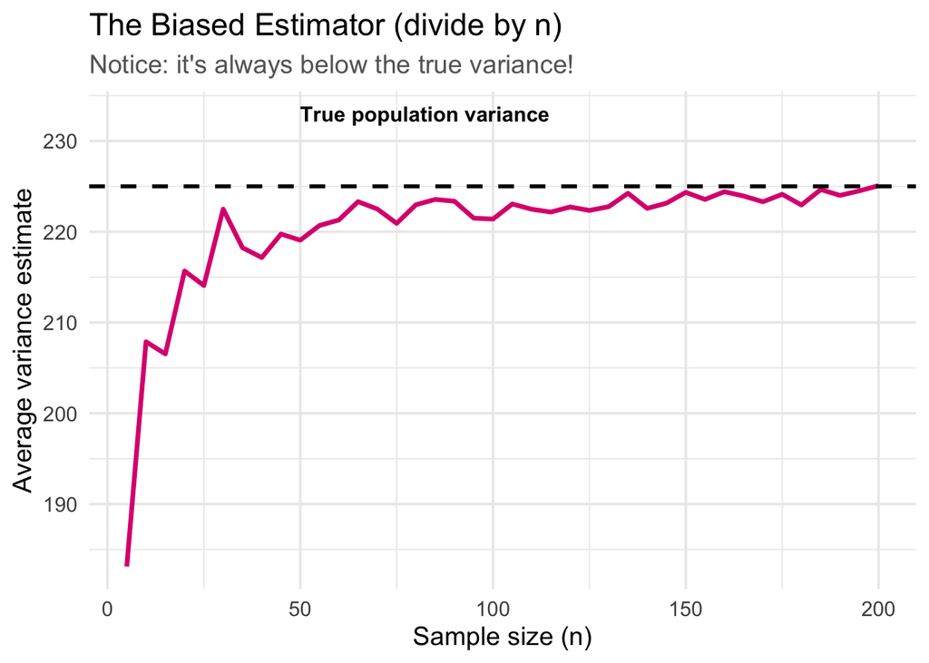

The red line consistently underestimates the true variance. This is **bias**!

## Illustration: Bessel’s correction fixes the bias

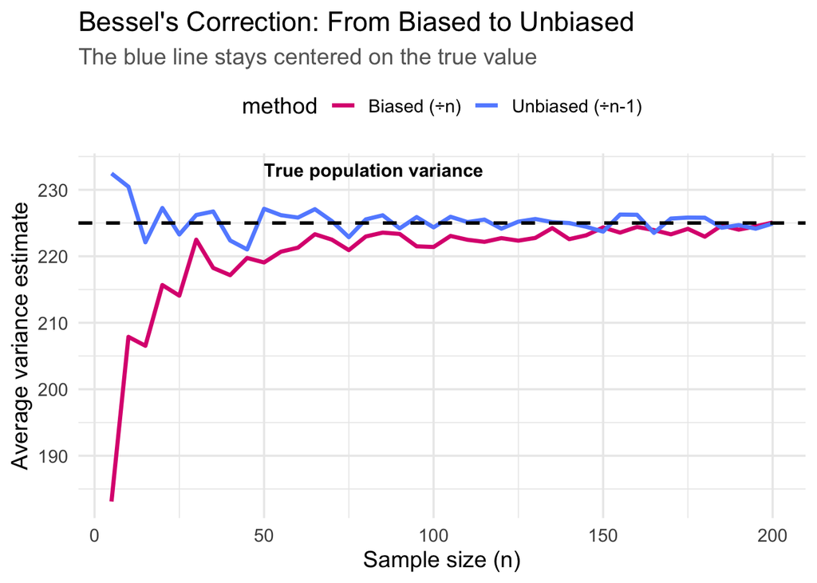

The blue line stays centered on the true value. **Bessel’s correction works!**

## Today’s lecture

1. Sampling: an example

2. Statistical inference

**3. Quantifying uncertainty**

# Quantifying uncertainty

## The big question

We now know:

1. ✓ The importance of random sampling
2. ✓ That samples vary: sampling variation
3. ✓ That larger samples are more precise
4. ✓ What makes a ``good’’ estimator (unbiasedness, consistency)

**But here’s the challenge:** we usually have only ONE sample.

How do we know how far our single estimate is from the true population parameter?

Answer: The **central limit theorem**!

## Central limit theorem

**The miraculous result:** For large samples, the sampling distribution of the sample mean is approximately **normal**, *regardless of the underlying distribution*!

**Formally:** Let $X_1, ..., X_n$ be i.i.d. random variables with $\mathbb{E}[X_i] = \mu$ and $\mathbb{V}(X_i) = \sigma^2 > 0$. Then:

$$\bar{X_n} \sim \mathcal{N}\left(\mu_{\bar{X_n}}, \sigma_{\bar{X_n}}^2 \right) = \mathcal{N} \left(\mu, \frac{\sigma^2}{n} \right) \quad \text{for large } n \text{ } (\geq 30)$$

Or equivalently (standardized mean):

$$Z_n = \sqrt{n}\frac{\bar{X_n} - \mu}{\sigma} \sim \mathcal{N}(0, 1)$$

## A quick refresher on the (standard) normal distribution

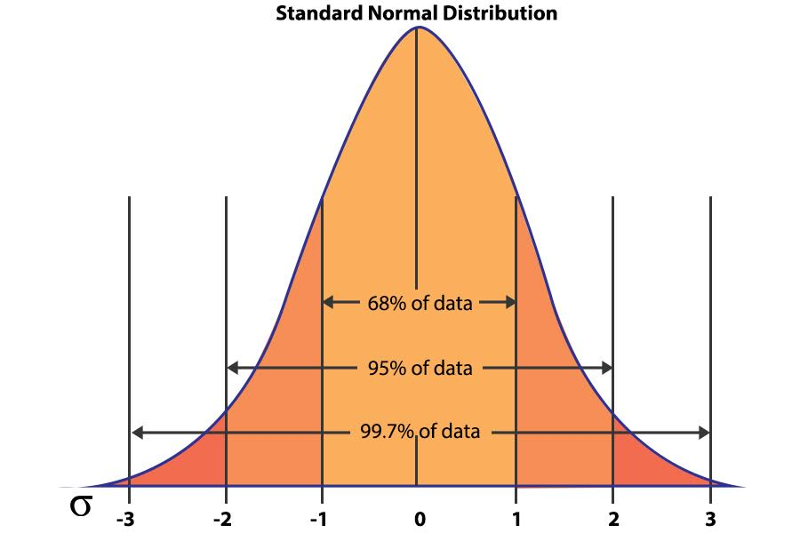

## Why the CLT is magical

- The CLT holds **regardless** of how the original $X_i$’s are distributed (uniform, skewed, anything!)
- It only requires $n$ to be **large enough** (rule of thumb: $n > 30$)
- This lets us use the **normal distribution** for inference, even without knowing the population distribution
- It’s the foundation of most statistical inference methods

## CLT in action: non-normal becomes normal!

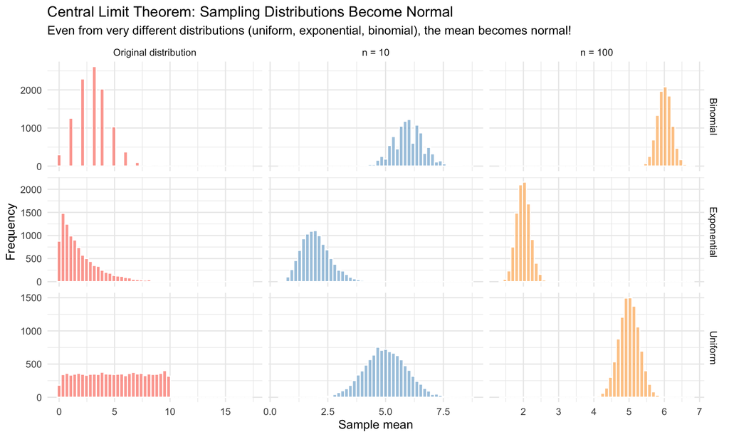

**See it?** Regardless of the original population distribution (uniform, exponential, binomial), as $n$ increases, the distribution of the sample mean becomes more and more **normal**! That’s the CLT!

## CLT for proportions

The CLT can just as easily be applied to a sample proportion, $\hat{p}$. Substitute $p = \mu$ and $p \cdot (1-p) = \sigma^2$ and you obtain:

$$Z_n = \sqrt{n}\frac{\hat{p} - p}{\sqrt{p \cdot (1-p)}} \sim \mathcal{N}(0, 1)$$

## `R` and normal distributions

We can use the normal distribution to find percentiles or probabilities. Without computers, we use a normal probability table, which lists Z scores and associated percentiles.

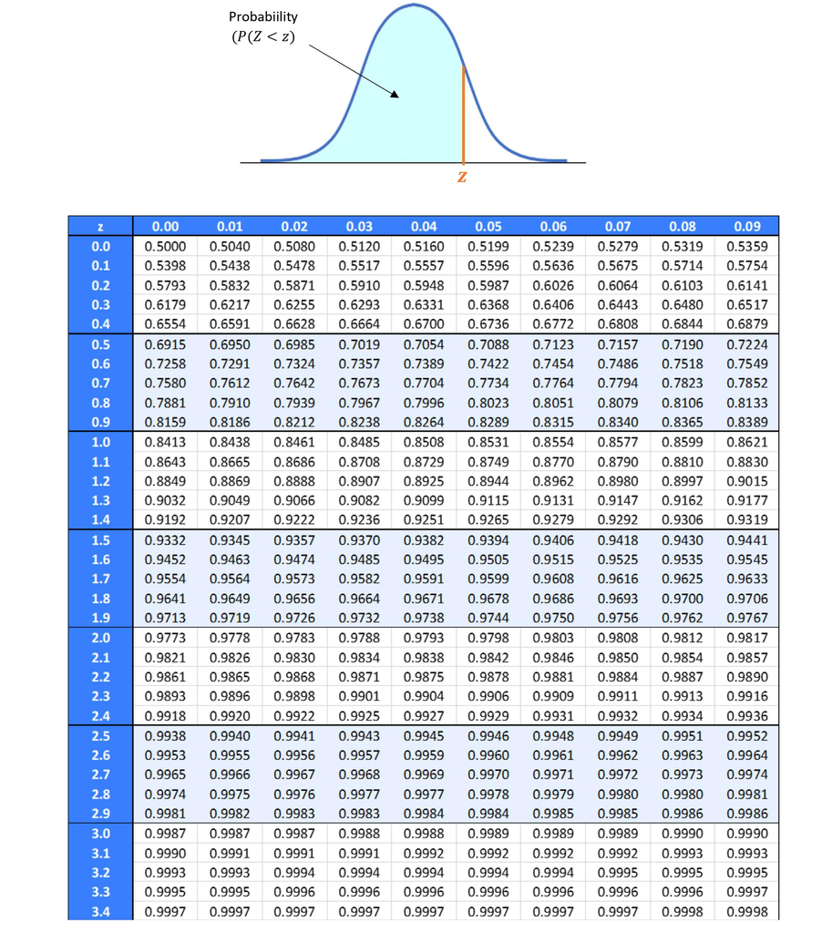

## `R` and normal distributions

We can use the normal distribution to find percentiles or probabilities. With `R`, the `pnorm` function gives us the probability associated with any cutoff on a normal curve.

```r
pnorm(q = 1, mean = 0, sd = 1)
```

```
[1] 0.8413447
```

```r
openintro::normTail(m = 0, s= 1, L = 1)
```

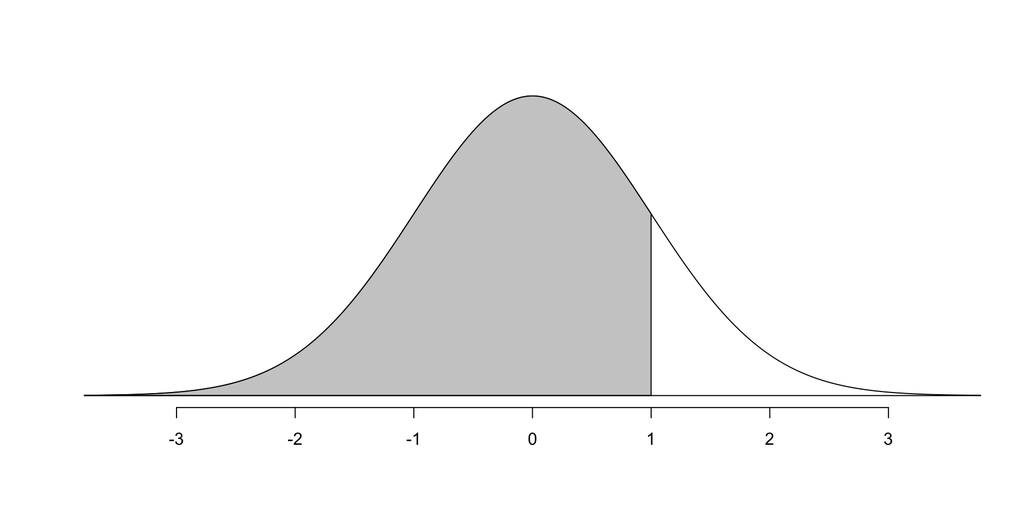

## `R` and normal distributions

We can use the normal distribution to find percentiles or probabilities. With `R`, the `pnorm` function gives us the probability associated with any cutoff on a normal curve.

```r
pnorm(q = 0, mean = 0, sd = 1)
```

```
[1] 0.5
```

```r
openintro::normTail(m = 0, s= 1, L = 0)
```

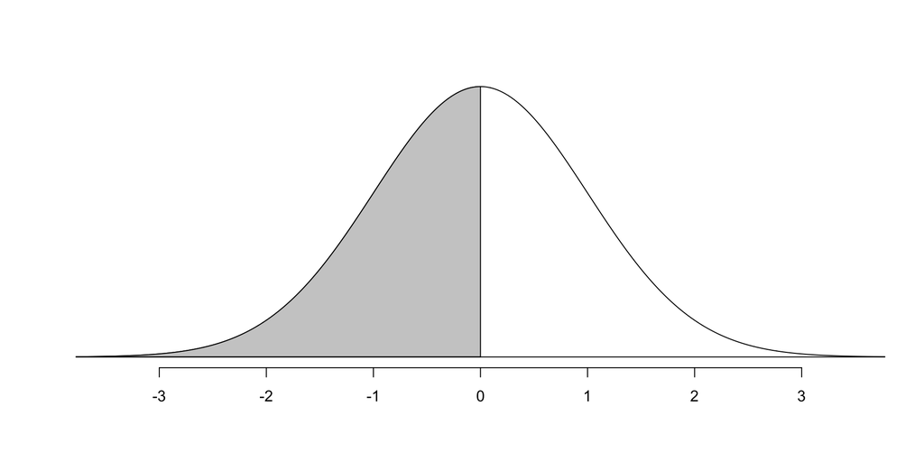